# Lab 2

```r
library(tidyverse)
tree_data <- read.csv("data/tree_dat.csv")

glimpse(tree_data)
```

```
Rows: 131,386
Columns: 8
$ treeID  <int> 1, 1, 1, 1, 1, 1, 1, 1, 1, 1, 1, 1, 1, 1, 1, 1, 1, 1, 1, 1, 1,…
$ standID <int> 1, 1, 1, 1, 1, 1, 1, 1, 1, 1, 1, 1, 1, 1, 1, 1, 1, 1, 1, 1, 1,…
$ stand   <chr> "A1", "A1", "A1", "A1", "A1", "A1", "A1", "A1", "A1", "A1", "A…
$ year    <int> 1960, 1961, 1962, 1963, 1964, 1965, 1966, 1967, 1968, 1969, 19…
$ species <chr> "ABBA", "ABBA", "ABBA", "ABBA", "ABBA", "ABBA", "ABBA", "ABBA"…
$ age     <int> 1, 2, 3, 4, 5, 6, 7, 8, 9, 10, 11, 12, 13, 14, 15, 16, 17, 18,…
$ inc     <dbl> 0.930, 0.950, 0.985, 0.985, 0.715, 0.840, 0.685, 0.940, 1.165,…
$ rad_ib  <dbl> 10.78145, 11.73145, 12.71645, 13.70145, 14.41645, 15.25645, 15…
```

Question 1: In the tree growth data set I see the analyzation of 2,291 different trees. For all the 2,291 different trees, age,linear growth (mm), estimated inside bark radius of tree at breast height at the end of the year of grow (mm) recorded for every year of their life. There were also 15 different tree species that were analyzed.

```r
stand1_records <- tree_data %>%
  filter(standID == 1) %>%
  nrow()

stand1_records
```

```
[1] 979
```

Question 2: Based on the output of the code above 979 records have made it to stand 1

```r
species_counts <- tree_data %>%
  filter(species %in% c("ABBA", "PIST")) %>%
  count(species)

species_counts
```

```
  species     n
1    ABBA 13033
2    PIST  4188
```

Question 3: Based on the output of the code above there have been 13,033 records of Abies balsamea specie and 4,188 records of the Pinus strobus specie.

```r
last_year <- max(tree_data$year)

old_trees <- tree_data %>%
  filter(year == last_year, age > 200) %>%
  nrow()

old_trees
```

```
[1] 7
```

Question 4:Bbased off of the code above there are 7 trees in the entire dataset that were over the age of 200 in the the last year

```r
oldest_tree <- tree_data %>%
  slice_max(age, n = 1)

oldest_tree
```

```
  treeID standID stand year species age  inc rad_ib
1     24       2    A2 2007    PIRE 269 0.37 308.84
```

Question 5: Based on the code that was ran above, the Pinus resinosa is the oldest tree in the dataset at 269 years old

```r
oldest_trees_2001 <- tree_data %>%
  filter(year == 2001) %>%
  slice_max(age, n = 5)

oldest_trees_2001
```

```
  treeID standID stand year species age   inc  rad_ib
1     24       2    A2 2001    PIRE 263 0.210 306.880
2     25       2    A2 2001    PIRE 259 0.280 156.210
3   1595      24    F1 2001    FRNI 212 0.579 156.267
4   1598      24    F1 2001    FRNI 206 0.394 130.251
5   1712      26    F3 2001    FRNI 206 0.168 154.354
```

Question 6: Based on the code that was ran above, the first and second oldest trees were the Pinus resinosa, and they were 263 and 259 years olds. The the next three oldest were Fraxinus nigras and they were the ages of 212, 206, and 206.

```r
sample_30_percent <- tree_data %>%
  filter(year == 2002) %>%
  slice_sample(prop = 0.3)

nrow(sample_30_percent)
```

```
[1] 687
```

Question 7: Based on the output of the code above, 687 trees are in a 30% sample of those recorded in 2002.

```r
top_trees_stand5_2007 <- tree_data %>%
  filter(standID == 5, year == 2007) %>%
  arrange(desc(rad_ib)) %>%
  slice_head(n = 3)

top_trees_stand5_2007$treeID
```

```
[1] 128 157 135
```

Question 8: Based on the code that has been written above, the three tree ID’s are 128, 157, 135.

```r
library(dplyr)


smallest_trees_2007_stand3 <- tree_data %>%
  select(treeID, stand, year, rad_ib) %>%
  filter(stand == 3, year == 2007) %>%
  slice_min(rad_ib, n = 3)

print(smallest_trees_2007_stand3)
```

```
[1] treeID stand  year   rad_ib
<0 rows> (or 0-length row.names)
```

```r
tree_data_no_stand <- tree_data %>%
  select(-stand)

glimpse(tree_data_no_stand)
```

```
Rows: 131,386
Columns: 7
$ treeID  <int> 1, 1, 1, 1, 1, 1, 1, 1, 1, 1, 1, 1, 1, 1, 1, 1, 1, 1, 1, 1, 1,…
$ standID <int> 1, 1, 1, 1, 1, 1, 1, 1, 1, 1, 1, 1, 1, 1, 1, 1, 1, 1, 1, 1, 1,…
$ year    <int> 1960, 1961, 1962, 1963, 1964, 1965, 1966, 1967, 1968, 1969, 19…
$ species <chr> "ABBA", "ABBA", "ABBA", "ABBA", "ABBA", "ABBA", "ABBA", "ABBA"…
$ age     <int> 1, 2, 3, 4, 5, 6, 7, 8, 9, 10, 11, 12, 13, 14, 15, 16, 17, 18,…
$ inc     <dbl> 0.930, 0.950, 0.985, 0.985, 0.715, 0.840, 0.685, 0.940, 1.165,…
$ rad_ib  <dbl> 10.78145, 11.73145, 12.71645, 13.70145, 14.41645, 15.25645, 15…
```

```r
tree_data_no_stand <- tree_data %>%
  select(-stand)  # Remove 'stand' column
```

Question 10: The output of the code is above

```r
tree_data_ID <- tree_data %>%
  select(contains("ID"))
glimpse(tree_data_ID)
```

```
Rows: 131,386
Columns: 2
$ treeID  <int> 1, 1, 1, 1, 1, 1, 1, 1, 1, 1, 1, 1, 1, 1, 1, 1, 1, 1, 1, 1, 1,…
$ standID <int> 1, 1, 1, 1, 1, 1, 1, 1, 1, 1, 1, 1, 1, 1, 1, 1, 1, 1, 1, 1, 1,…
```

Question 11: The output of the code is above

```r
tree_data_ID_stand <- tree_data %>%
  select(contains("ID") | contains("stand"))

glimpse(tree_data_ID_stand)
```

```
Rows: 131,386
Columns: 3
$ treeID  <int> 1, 1, 1, 1, 1, 1, 1, 1, 1, 1, 1, 1, 1, 1, 1, 1, 1, 1, 1, 1, 1,…
$ standID <int> 1, 1, 1, 1, 1, 1, 1, 1, 1, 1, 1, 1, 1, 1, 1, 1, 1, 1, 1, 1, 1,…
$ stand   <chr> "A1", "A1", "A1", "A1", "A1", "A1", "A1", "A1", "A1", "A1", "A…
```

Question 12:The output of the code is above.

```r
tree_data <- tree_data %>%
  rename(
    rad_ib_mm = rad_ib,
    inc_mm = inc
  )

glimpse(tree_data)
```

```
Rows: 131,386
Columns: 8
$ treeID    <int> 1, 1, 1, 1, 1, 1, 1, 1, 1, 1, 1, 1, 1, 1, 1, 1, 1, 1, 1, 1, …
$ standID   <int> 1, 1, 1, 1, 1, 1, 1, 1, 1, 1, 1, 1, 1, 1, 1, 1, 1, 1, 1, 1, …
$ stand     <chr> "A1", "A1", "A1", "A1", "A1", "A1", "A1", "A1", "A1", "A1", …
$ year      <int> 1960, 1961, 1962, 1963, 1964, 1965, 1966, 1967, 1968, 1969, …
$ species   <chr> "ABBA", "ABBA", "ABBA", "ABBA", "ABBA", "ABBA", "ABBA", "ABB…
$ age       <int> 1, 2, 3, 4, 5, 6, 7, 8, 9, 10, 11, 12, 13, 14, 15, 16, 17, 1…
$ inc_mm    <dbl> 0.930, 0.950, 0.985, 0.985, 0.715, 0.840, 0.685, 0.940, 1.16…
$ rad_ib_mm <dbl> 10.78145, 11.73145, 12.71645, 13.70145, 14.41645, 15.25645, …
```

Question 13: The output of the code is above.

```r
tree_data <- tree_data %>%
  mutate(
    rad_ib_cm = rad_ib_mm / 10,
    DBH_cm = rad_ib_cm * 2,
    BA_m2 = 0.00007854 * (DBH_cm^2)
  )

mean_BA_POTR_2007 <- tree_data %>%
  filter(species == "POTR", year == 2007) %>%
  summarise(mean_BA_m2 = mean(BA_m2, na.rm = TRUE))

mean_BA_POTR_2007
```

```
  mean_BA_m2
1 0.03696619
```

```r
tree_data <- tree_data %>%
  mutate(established = if_else(age > 5, TRUE, FALSE))

count_established <- tree_data %>%
  count(established)

count_established
```

```
  established      n
1       FALSE   8883
2        TRUE 122503
```

Question 15: Based of of the output of the code above, there are 122,503 records of established trees.

```r
tree_data <- tree_data %>%
  mutate(
    DBH_class = case_when(
      DBH_cm >= 0 & DBH_cm < 2.5  ~ "seedling",
      DBH_cm >= 2.5 & DBH_cm < 10 ~ "sapling",
      DBH_cm >= 10 & DBH_cm < 30  ~ "pole",
      DBH_cm >= 30                ~ "sawlog",
      TRUE ~ NA_character_
    )
  )


DBH_class_counts_2007 <- tree_data %>%
  filter(year == 2007) %>%
  count(DBH_class)

DBH_class_counts_2007
```

```
  DBH_class    n
1      pole 1963
2   sapling  252
3    sawlog   76
```

Question 16: Based on the output of the code above, the pole class had 1,963 counts, the sapling class has 252 counts, and the sawlog class had 76 counts.

```r
DBH_summary_2007 <- tree_data %>%
  filter(year == 2007) %>%
  summarize(
    mean_DBH_cm = mean(DBH_cm, na.rm = TRUE),
    sd_DBH_cm = sd(DBH_cm, na.rm = TRUE)
  )


DBH_summary_2007
```

```
  mean_DBH_cm sd_DBH_cm
1    16.09351  6.138643
```

Question 17: Based on the output of the code above, the mean dbh was 16.09351cm and the sd of the dbh was 6.138643cm.

```r
species_age_2003 <- tree_data %>%
  filter(year == 2003) %>%
  group_by(species) %>%
  summarize(mean_age = mean(age, na.rm = TRUE)) %>%
  arrange(desc(mean_age))


oldest_species_2003 <- species_age_2003 %>%
  slice_head(n = 3)

oldest_species_2003
```

```
# A tibble: 3 × 2
  species mean_age
  <chr>      <dbl>
1 THOC       127.
2 FRNI        83.1
3 PIST        73.3
```

Question 18: Based on output of the code above, the three species with the oldest men age are Thuja occidentalis, Fraxinus nigra, and PIST

```r
year_summary <- tree_data %>%
  summarize(
    num_unique_years = n_distinct(year),
    first_year = min(year, na.rm = TRUE),
    last_year = max(year, na.rm = TRUE)
  )

year_summary
```

```
  num_unique_years first_year last_year
1              111       1897      2007
```

Question 19: Based on the output of the code above, there are 111 unique years.

```r
stand_years <- tree_data %>%
  group_by(stand) %>%
  summarize(num_years = n_distinct(year)) %>%
  arrange(desc(num_years))


max_years <- max(stand_years$num_years)

largest_stands <- stand_years %>%
  filter(num_years == max_years)

largest_stands
```

```
# A tibble: 5 × 2
  stand num_years
  <chr>     <int>
1 A1          111
2 D1          111
3 D2          111
4 D3          111
5 F1          111
```

Question 20: Based on the output above stands A1, D1, D2, D3, and F1 were all tied with 111 years.

```r
library(dplyr)
library(ggplot2)


growth_rates <- tree_data %>%
  arrange(species, treeID, year) %>%
  group_by(treeID) %>%
  mutate(annual_growth = DBH_cm - lag(DBH_cm)) %>%
  filter(!is.na(annual_growth)) %>%
  summarise(
    total_years = n(),
    avg_growth = mean(annual_growth, na.rm = TRUE),
    sd_growth = sd(annual_growth, na.rm = TRUE),
    species = first(species),
    .groups = "drop"
  ) %>%
  filter(total_years >= 10) %>%
  group_by(species) %>%
  summarise(
    species_avg_growth = mean(avg_growth, na.rm = TRUE),
    species_sd_growth = mean(sd_growth, na.rm = TRUE),
    .groups = "drop"
  )


fastest_species <- growth_rates %>%
  arrange(desc(species_avg_growth)) %>%
  slice_head(n = 3)

slowest_species <- growth_rates %>%
  arrange(species_avg_growth) %>%
  slice_head(n = 3)

print(fastest_species)
```

```
# A tibble: 3 × 3
  species species_avg_growth species_sd_growth
  <chr>                <dbl>             <dbl>
1 PIRE                 0.417             0.191
2 PIBA                 0.362             0.217
3 POTR                 0.351             0.170
```

```r
print(slowest_species)
```

```
# A tibble: 3 × 3
  species species_avg_growth species_sd_growth
  <chr>                <dbl>             <dbl>
1 THOC                 0.154            0.0674
2 LALA                 0.172            0.0962
3 QURU                 0.177            0.0688
```

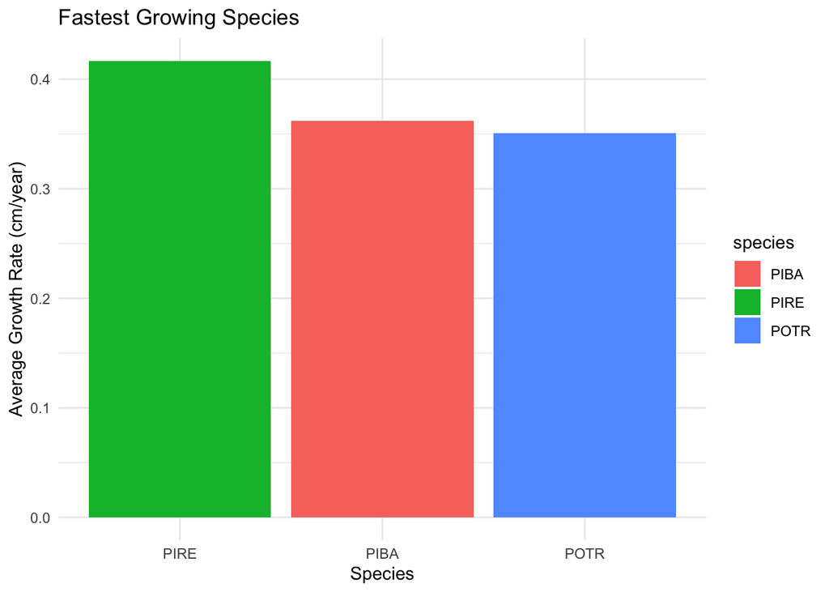

```r
if (!dir.exists("images")) {
  dir.create("images")
}


fastest_plot <- ggplot(fastest_species, aes(x = reorder(species, -species_avg_growth), y = species_avg_growth, fill = species)) +
  geom_bar(stat = "identity") +
  labs(title = "Fastest Growing Species", x = "Species", y = "Average Growth Rate (cm/year)") +
  theme_minimal()

fastest_plot <- ggplot(fastest_species, aes(x = reorder(species, -species_avg_growth), y = species_avg_growth, fill = species)) +
  geom_bar(stat = "identity") +
  labs(title = "Fastest Growing Species", x = "Species", y = "Average Growth Rate (cm/year)") +
  theme_minimal()

fastest_plot
```